# Specifications for MSE Trials for North Atlantic Albacore

## 1 Introduction

The North Atlantic Albacore (N-ALB) fishery, under the management of the International Commission for the Conservation of Atlantic Tuna (ICCAT), is undergoing a management strategy evaluation (MSE) process.

**NoteManagement strategy evaluation**

Process used in fisheries management to simulate and assess the performance of different management strategies under varying conditions and uncertainties (Figure 1).

There are three main components in an MSE process:

- **Operating models (OMs)**: a collection of mathematical/statistical models that describe alternative hypotheses of the historical fishery dynamics and specifications for simulating the collection of data and implementation of management measures in the future;
- **Candidate management procedures (CMPs)**: a set of proposed algorithms that generate management recommendations from fishery data and will be evaluated in the MSE;
- **Performance indicators (PIs)**: statistics used to quantitatively evaluate the CMPs against specified management objectives.

The OMs, CMPs, and PIs are developed as a collaborative effort between scientists, decision-makers, and other stakeholders in the fishery.

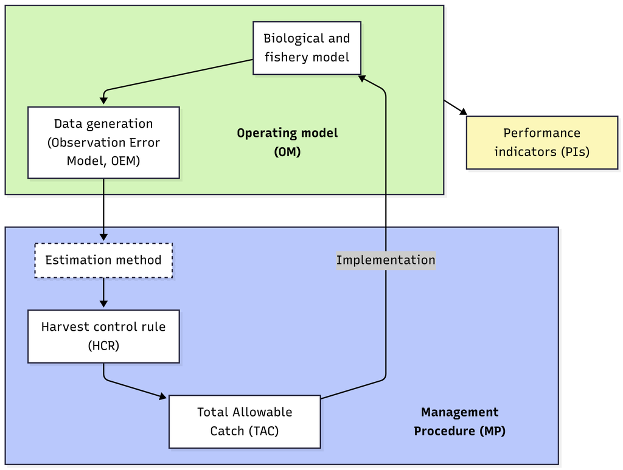

Figure 1: Management strategy evaluation (MSE) framework.

### 1.1 About this document

This document describes the specifications for the OMs, CMPs, and PIs that have been proposed and developed for the N-ALB fishery. It is a living document and will be continued to be updated so that it reflects the current state of the N-ALB MSE process. Members of the Albacore Species Group (ALBSG) are encouraged to provide feedback, comments, or edits to any part of this document.

The document is written using the [Quarto](https://quarto.org/) format and can edited in any text editor. The source document is available on the [MSE GitHub repository](https://github.com/ICCAT/nalb-mse-2). ALBSG members can make edits to the document either directly in the online repository or by cloning the repository and submitting pull requests with their edits. Alternatively, they can email questions or comments to the MSE developers. The former approach has the advantage that all comments, questions, and edits are immediately visible to all members of the ALBSG. The [Discussions feature](https://docs.github.com/en/discussions/quickstart#creating-a-new-discussion) on the Github repository can also be used to post questions, comments, or points for discussion related to any aspect of this document or the MSE process in general.

This document is available at the [N-ALB MSE homepage](https://iccat.github.io/nalb-mse-2/).

## 2 MSE framework

The R software has been used to developed the MSE code for the N-ALB fishery. All code is open-source and can be found on the [MSE GitHub repository](https://github.com/ICCAT/nalb-mse-2).

The code developed for the N-ALB MSE uses the FLBEIA framework. FLBEIA (Garcia et al., 2017) is an R package that has been developed for conducting bio-economic evaluation of fisheries management strategies. The software allows the bio-economic evaluation of a wide range of management strategies in a great variety of case studies such as multi-stock, multi-fleet, stochastic and seasonal configurations. FLBEIA is built using FLR libraries. [FLR](https://flr-project.org/) is a collaborative project oriented to develop quantitative fisheries management tools.

## 3 Stock assessment

Previously, the N-ALB OMs were based on the 2013 stock assessment (Merino et al., 2020, 2014) using the MULTIFAN-CL platform (Fournier et al., 1998).

A new stock assessment was conducted in 2023 (ICCAT, 2023) using the Stock Synthesis (SS3) platform (Methot and Wetzel, 2013). The N-ALB OMs have been updated based on this new assessment.

The data used in the 2023 N-ALB assessment as well as the structure and assumptions of the assessment model are summarized in the sections below.

Table 1: Fishing fleets included the 2023 N-ALB stock assessment. The last column indicates if the fleet had an associated index of abundance (catch-per-unit-effort, CPUE).

| Fleet code | Description | CPUE included? |
| --- | --- | --- |
| 1_BB | Baitboat (Spain, France) | Yes |
| 2_BB_isl | Baitboat islands (Portugal Madeira/Azores, Spain Canary) for quarters 1, 3, and 4 | No |
| 3_TR_GN | Troll (Spain, France) and Gillnets (France, Ireland) | No |
| 4_MWT | Mid-water trawl (France, Ireland) | No |
| 5_JPLL_N | Japan longline north 30 | Yes |
| 6_JPLL_S | Japan longline south 30 | Yes |
| 7_TAILL_N | Taiwan longline north 30 | Yes |
| 8_TAILL_S | Taiwan longline south 30 | Yes |
| 9_USLL_N | US and Canada longline north 30 | Yes |
| 10_USLL_S | US longline south 30 | Yes |
| 11_VENLL | Venezuela longline | Yes |
| 12_MIX_KR_PA | Mixed flags longline (KR, PA, CHN) | No |
| 13_OthLL | Other longline | No |
| 14_OthSurf | Other surface gears | No |
| 15_BBisl_s2 | Baitboat islands (Portugal Madeira/Azores, Spain Canary) for quarter 2 | No |

### 3.1 Data

The period covered was from 1930 to 2021. The assessment mainly used landings data from longline (LL) and baitboat (BB) fleets, with a total of 15 fleets included in the model (Table 1 and Figure 2). There were seven LL and one BB (Spain and France) catch-per-unit-effort (CPUE) indices (Figure 3). The catchability coefficients for the CPUE indices were assumed to be time-invariant.

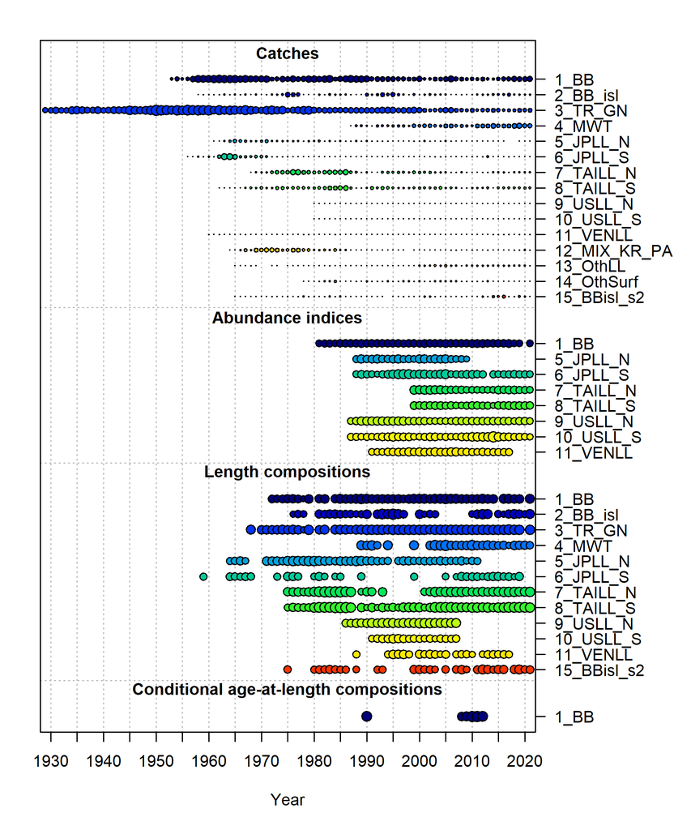

Figure 2: Summary of the data used in the 2023 N-ALB stock assessment. The bubble size represents the quantity or precision of the data.

Length composition data from 12 fleets were included in the model, mostly from LL and BB fleets and for the period after 1970 (Figure 2). The effective sample size (ESS) for the length composition data was established by adjusting ESS until unity was reached between modeled ESS and the Francis suggested sample size (Francis, 2011). Conditional age-at-length (CAAL) data was also included for the BB (France and Spain) fleet.

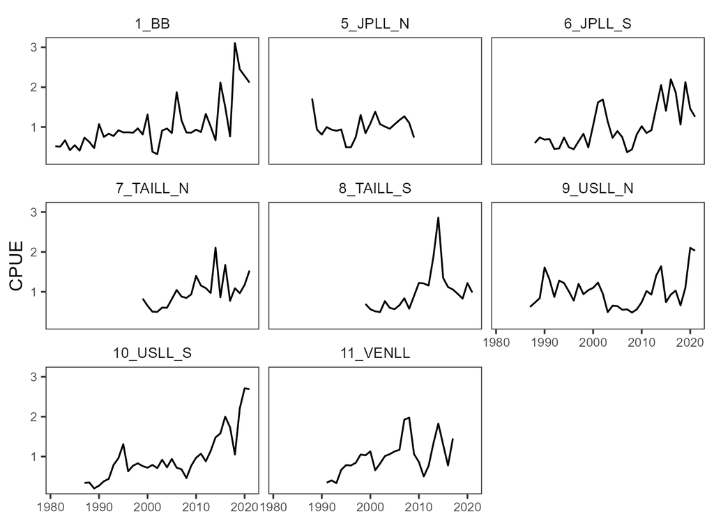

Figure 3: Indices of abundance (CPUE) by fleet included in the N-ALB assessment model.

### 3.2 Model structure

The model was configured yearly (one season per year), one sex, one area, and a total of 16 age groups (0 to 15+). The spawning timing was January 1st.

### 3.3 Biological Parameters

Natural mortality (M) was age-specific and parametrized following Lorenzen (1996), with a reference M equal to 0.36 for age 6 based on the assumption of a maximum age of 15 years (Hamel and Cope, 2022). Maturity-at-age was knife-edge, with 50% at age-5 and 100% thereafter. Fecundity was proportional to body weight. Growth was parametrized following the von Bertalanffy curve (Schnute, 1981) and parameters were estimated within the model. Variability of lengths-at-age was assumed to be a function of age. Figure 4 shows a summary of the biological parametrization.

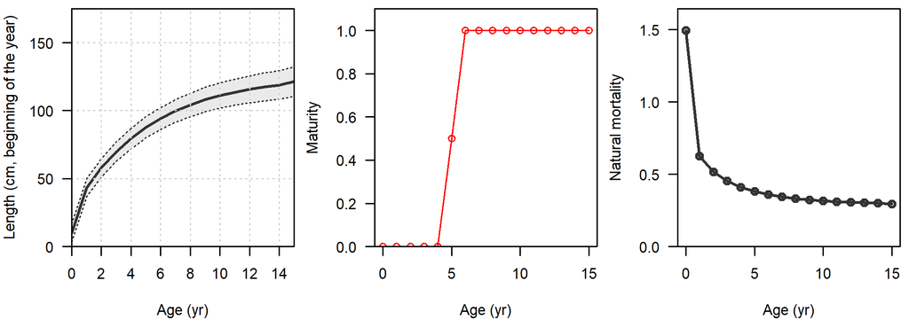

Figure 4: Growth, maturity, and natural mortality parametrized in the N-ALB assessment model.

### 3.4 Stock-Recruitment

Expected recruitment to age-0 was calculated from the total spawning stock biomass using the Beverton-Holt stock-recruit function. Recruitment settlement was assumed to occur at month 6. The standard error for the log-normally distributed recruitment deviations (sigmaR) was fixed to 0.4. Steepness (h) was estimated within the model with a prior of 0.75 taken from the 2013 assessment.

### 3.5 Selectivity

Selectivity was modelled as a function of length. Dome-shaped selectivity was allowed for several LL and BB fleets, while an asymptotic selectivity was speficied for the US and Venezuela LL fleets. Splines were also used for the BB (Spain and France) and mid-water trawl. Time blocks were specified for some fleets due to changes in length composition data.

## 4 Operating Models

### 4.1 Reference OMs

During 2023 and 2024, the ALBSG developed a set of OMs considering variations in natural mortality (*M*), variability in recruitment (*sigmaR*), and the weighting of the following data sources:

- Base case (no change)
- Upweight ($\lambda=2$) CPUE data
- Upweight ($\lambda=2$) size (i.e., length composition) data
- Upweight ($\lambda=2$) age (i.e., CAAL) data

Per weighting scenario, 400 models were run in SS3 by randomly varying the M and sigmaR values sampled from a normal distribution with mean 0.36 and 0.4, respectively, and a coefficient of variation of 0.2 (Figure 5).

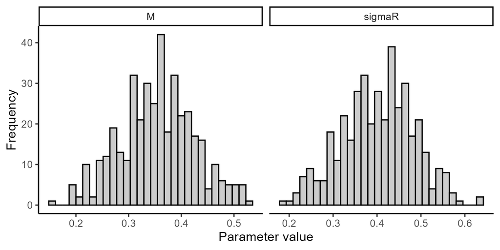

Figure 5: Values of natural mortality (M) and recruitment variability (sigmaR) simulated in the OMs.

Then, 100 models per weighting scenario were selected based on maximum gradient, likelihood, and the ratio of virgin and spawning biomass values in order to remove unrealistic or nonconvergent runs. We consider this final set of 400 models (100 models per weighting scenario) as our Reference OMs.

### 4.2 Robustness OMs

The robustness scenarios explored the impacts of changes in $R_0$ and recruitment variability:

- Increase in mean recruitment level: the $R_0$ parameter of the Beverton-Holt relationship increased by 20% in the projection period with respect to the values used in the Reference OMs
- Decrease in mean recruitment level: the $R_0$ parameter of the Beverton-Holt relationship decreased by 20% in the projection period with respect to the values used in the Reference OMs
- Increase in recruitment variability: the sigmaR parameter increased by 20% in the projection period with respect to the values used in the Reference OMs

All CMPs were also tested for the Robustness OMs.

### 4.3 Validation

#### 4.3.1 Summary Report

A Summary Report summarizes the estimated parameters, the calculated biological reference points, and the estimated stock status relative to those reference points, across the 400 Reference OMs.

#### 4.3.2 Diagnostic Reports

|  | M | sigmaR |  |
| --- | --- | --- | --- |
| BaseCase |  |  |  |
| Smallest M value | 0.20 | 0.40 | See diagnostics |
| Medium M value | 0.36 | 0.26 | See diagnostics |
| Largest M value | 0.52 | 0.33 | See diagnostics |
| Smallest sigmaR value | 0.36 | 0.22 | See diagnostics |
| Medium sigmaR value | 0.36 | 0.40 | See diagnostics |
| Largest sigmaR value | 0.27 | 0.56 | See diagnostics |
| CPUE |  |  |  |
| Smallest M value | 0.15 | 0.24 | See diagnostics |
| Medium M value | 0.36 | 0.35 | See diagnostics |
| Largest M value | 0.53 | 0.49 | See diagnostics |
| Smallest sigmaR value | 0.34 | 0.18 | See diagnostics |
| Medium sigmaR value | 0.37 | 0.41 | See diagnostics |
| Largest sigmaR value | 0.43 | 0.63 | See diagnostics |
| Size |  |  |  |
| Smallest M value | 0.20 | 0.32 | See diagnostics |
| Medium M value | 0.36 | 0.27 | See diagnostics |
| Largest M value | 0.52 | 0.33 | See diagnostics |
| Smallest sigmaR value | 0.36 | 0.22 | See diagnostics |
| Medium sigmaR value | 0.40 | 0.40 | See diagnostics |
| Largest sigmaR value | 0.27 | 0.56 | See diagnostics |
| Age |  |  |  |
| Smallest M value | 0.22 | 0.35 | See diagnostics |
| Medium M value | 0.35 | 0.41 | See diagnostics |
| Largest M value | 0.50 | 0.47 | See diagnostics |
| Smallest sigmaR value | 0.36 | 0.20 | See diagnostics |
| Medium sigmaR value | 0.32 | 0.43 | See diagnostics |
| Largest sigmaR value | 0.43 | 0.63 | See diagnostics |

### 4.4 Conditioning

The Reference OMs were conditioned in FLBEIA with the same biological configuration and fleet structure of the SS3 models (Table 1). Two main periods are modelled in the MSE framework: historical and simulation periods (Figure 6), with important differences in the data generation and observation error model (OEM).

[output not shown]

Figure 6: Periods in the MSE and main differences between them.

#### 4.4.1 Observation error model

Autocorrelation in CPUE residuals were introduced in the simulations based on a previous analysis of CPUE residuals in the stock assessment model (Table 3). This observation error was introduced both in the historical and projection period for all the Reference OMs.

Table 3: Evaluation of temporal autocorrelation in CPUE residuals for lag 1. $\rho$ and $\sigma$ represent the correlation parameter and the standard deviation of residuals, respectively. ACF is the autocorrelation function. The only fleet that assumed a $\rho=0$ in the MSE was $1_BB$.

[output not shown]

## 5 Candidate Management Procedures

The management advice is given every three years (*management period*) and the total allowable catch (TAC) is derived from the candidate MP. The candidate MP was run in the last year of each management period, including information up to the previous year. The TAC derived from the MP was set for the next management period (Figure 7).

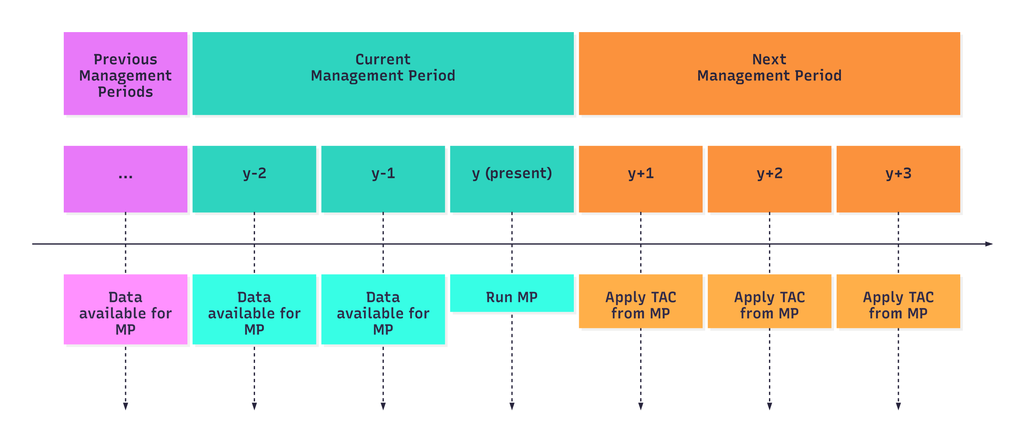

Figure 7: Representation of the TAC calculation for the next management period.

### 5.1 Pseudo-constant catch

The total allowable catch (TAC) for the next management period ($\{y+1,y+2,y+3\}$) is assumed constant, unless $\bar{J}$, derived from a group of indices of abundance in the last three years, falls below a reference value $J_{ref}=1.08$ (see Figure 8):

$$TAC_{\{y+1,y+2,y+3\}} =
\begin{cases}
TAC_{ct}, & \text{if }\bar{J} \geq J_{ref} \\
TAC_{ct}(\frac{\bar{J}}{J_{ref}}), & \text{if }\bar{J} < J_{ref}
\end{cases}$$

where $TAC_{ct}=42,000$ tonnes. $J_{ref}$ was set equal to the value observed in 2010, which is the most recent year when $SSB>SSB_{msy}$ after a period of $SSB<SSB_{msy}$. In order to derive $\bar{J}$, we first calculated a *combined* index of abundance ($J_Y$) for every year $Y$, where $Y\in \{y-1,...,y-3\}$:

$$J_Y = \frac{\sum_{i=1}^{n_i}I_{i,Y}w_{i}}{\sum_{i=1}^{n_i}w_{i}} \tag{1}$$

where $n_i$ represents the number of selected indices, $I_{i,Y}$ represents the value of index $i$ in year $Y$, and $w_{i}$ is the weighting factor. $w_{i}$ is derived from the standard deviation ($\sigma$) and temporal autocorrelation ($\rho$) of indices residuals:

$$w_{i}=\frac{1}{\sqrt{\sigma_i/(1-\rho_i)}} \tag{2}$$

The selected indices of abundance $I_i$ were those used in the 2023 assessment (excluding the historical ones):

- Spanish baitboat ($1\_BB$)
- Japanese longline index from southern region ($6\_JPLL\_S$)
- Taiwanese longline index from northern region ($7\_TAILL\_N$)
- Taiwanese longline index from southern region ($8\_TAILL\_S$)
- US longline index from northern region ($9\_USLL\_N$)
- US longline index from southern region ($10\_USLL\_S$)

We then calculate $\bar{J}$ as the average of the $J_{Y}$ values:

$$\bar{J} = \frac{J_{y-1}+J_{y-2}+J_{y-3}}{3}$$

In addition, the TAC variation between consecutive management periods $TAC_{\{y+1,y+2,y+3\}}$ and $TAC_{\{y-2,y-1,y\}}$ could not exceed 15%.

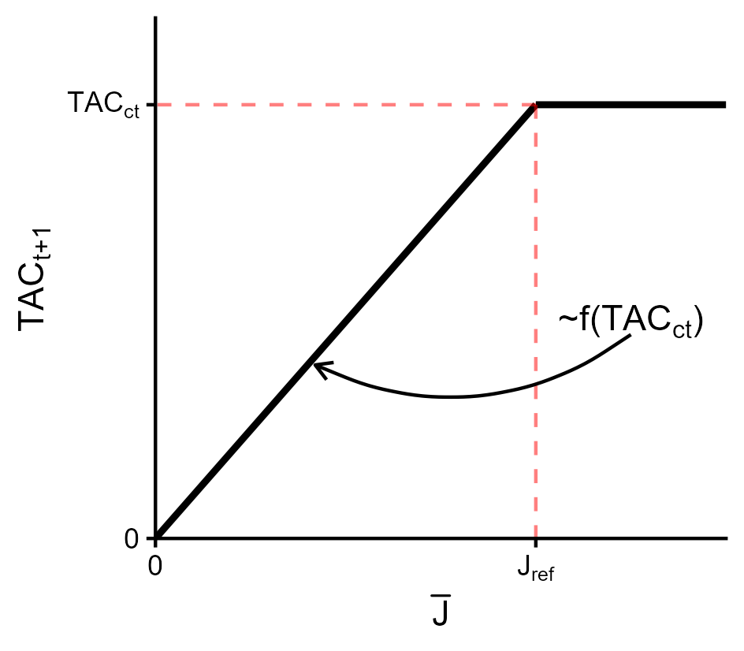

Figure 8: Derivation of the TAC for the next management period ($TAC_{t+1}$) in the pseudoconstant catch MP.

### 5.2 Index-based

The total allowable catch (TAC) for the next management period ($\{y+1,y+2,y+3\}$) is calculated from the TAC in the current management period $\{y-2,y-1,y\}$ and a factor $J_{rat}$ derived from a selected indices (see Section 5.1). First, we used Equation 1 and Equation 2 to calculate a *combined* index of abundance ($J_Y$) for every year $Y$, where $Y\in \{y-1,...,y-6\}$.

Once $J_Y$ is calculated, we then derive the ratio of change in $J$ between the last three years ($y-1$, $y-2$, and $y-3$) and the preceding three years ($y-4$, $y-5$, and $y-6$, Figure 9):

$$J_{rat} = \frac{J_{y-1}+J_{y-2}+J_{y-3}}{J_{y-4}+J_{y-5}+J_{y-6}}$$

Finally, the TAC for the next management period is obtained:

$$TAC_{\{y+1,y+2,y+3\}} = J_{rat} TAC_{\{y-2,y-1,y\}}$$

We imposed two types of restriction on the TAC variation between consecutive management periods $TAC_{\{y+1,y+2,y+3\}}$ and $TAC_{\{y-2,y-1,y\}}$:

- Maximum increase of 25% and decrease of 20%, or
- Maximum increase and decrease of 10%

In addition, $TAC_{\{y+1,y+2,y+3\}}$ was restricted to a maximum TAC of 50,000 tonnes.

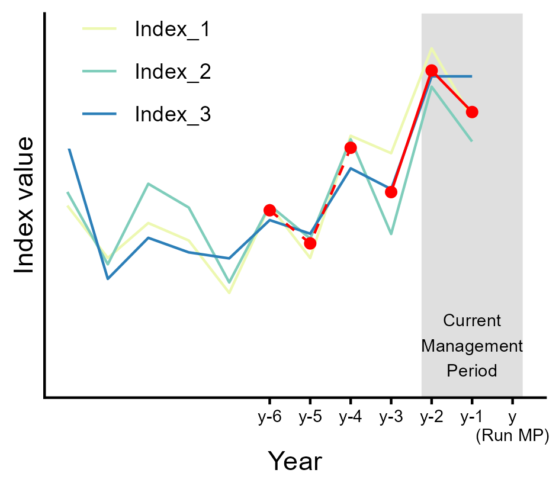

Figure 9: Example of the derivation of $J_Y$ from a set of indices. The red line represents $J_Y$ for the previous six years.

### 5.3 Model-based

Based upon the stochastic surplus production model in continuous time (SPiCT, Pedersen and Berg (2017)). SPiCT is a full state-space model, where biomass and fishing dynamics are modelled as states, which are observed indirectly through biomass indices and commercial catches sampled with error. SPiCT calculates maximum sustainable yield (MSY) reference points and allows to run short-term projections.

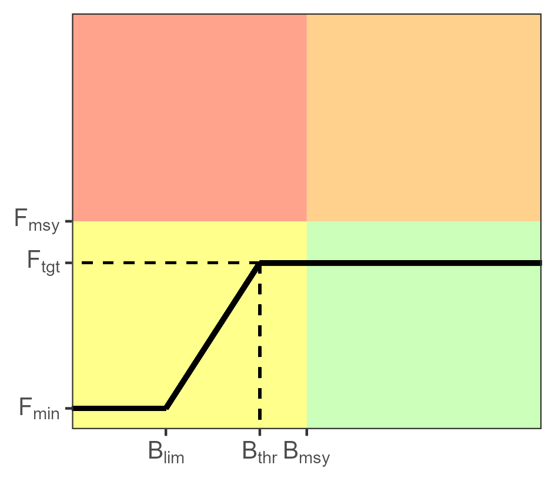

Figure 10: Example of HCR in model-based MPs.

The data generated from the OMs and the OEM is included in SPiCT to estimate the stock status in the final year of each management period and then apply a HCR (Figure 10) to derive the TAC for the next management period. In the HCR, $F_{tgt}$ and $B_{thr}$ need to be defined, and the following options were tested (Figure 11):

- $F_{tgt}=0.8F_{msy}$ and $B_{thr}=B_{msy}$
- $F_{tgt}=F_{msy}$ and $B_{thr}=B_{msy}$

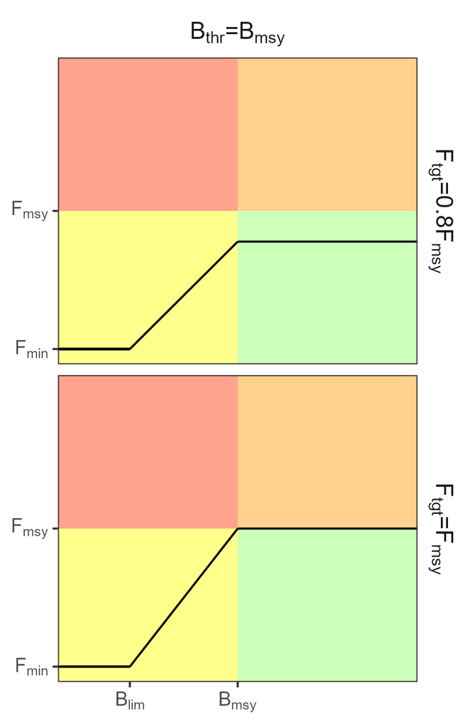

Figure 11: Harvest control rules (HCR) evaluated in this MSE.

It was assumed that $B_{lim}=0.4\times B_{msy}$ and $F_{min}=0.1\times F_{msy}$ for all cases as in Recommendation 21-04. These model-based CMPs were divided into two groups, depending on the maximum allowed variation between $TAC_{\{y+1,y+2,y+3\}}$ and $TAC_{\{y-2,y-1,y\}}$:

- Maximum increase or decrease of 10%, or
- Maximum increase of 25% and decrease of 20%

In addition, $TAC_{\{y+1,y+2,y+3\}}$ was restricted to a maximum TAC of 50,000 tonnes.

## 6 Performance Indicators

14 PIs have been developed for the N-ALB MSE (Table 4). These PIs are grouped into four types:

- **Status**: indicators related to stock status
- **Safety**: indicators related to the probability of the stock not falling below the biological reference points
- **Yield**: indicators related to the catch or TAC in the simulation years
- **Stability**: indicators related to the variation in TAC between management cycles

Each PI was calculated for every iteration in the Reference and Robustness OMs. Examples of each PI are given below.

Table 4: Performance indicators and description. These indicators were calculated for every OM iteration and only considering the simulation period.

[output not shown]

### 6.1 Examples

#### 6.1.1 Status

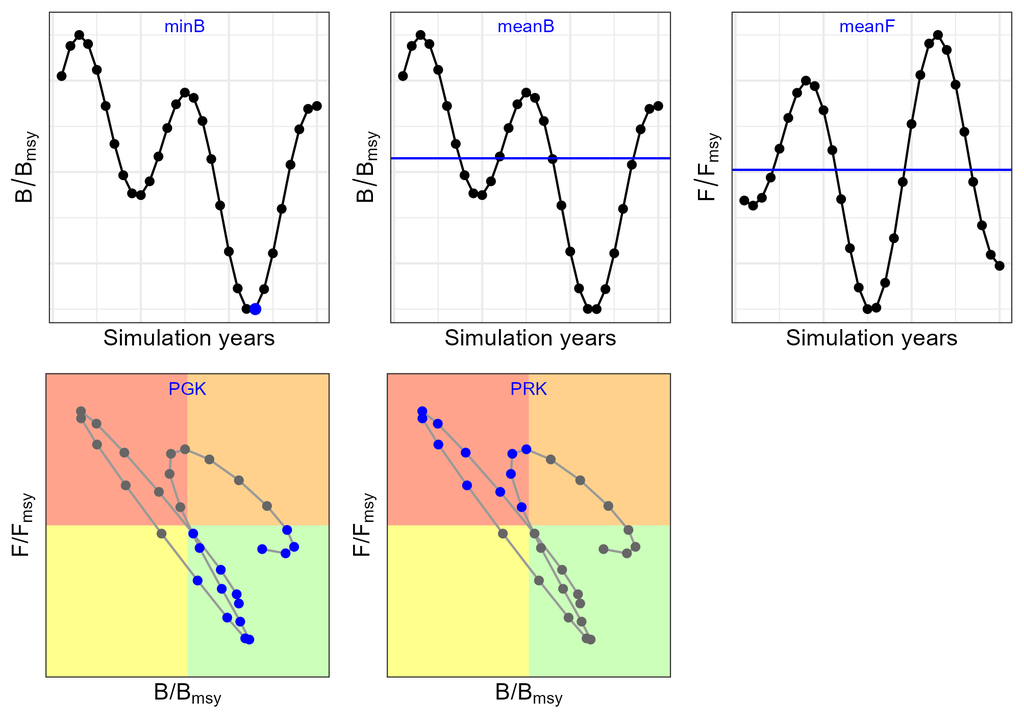

Figure 12: Status performance indicators. The blue dots or lines indicate the meaning of the metric. Find more details in Table 4.

#### 6.1.2 Safety

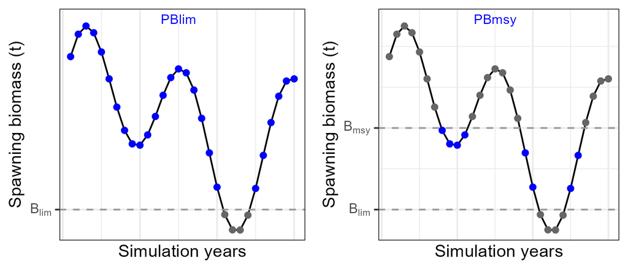

Figure 13: Safety performance indicators. The blue dots indicate the meaning of the metric. Find more details in Table 4.

#### 6.1.3 Yield

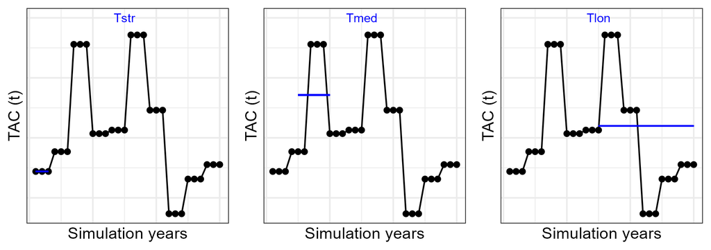

Figure 14: Yield performance indicators. The blue lines indicate the meaning of the metric. Find more details in Table 4.

#### 6.1.4 Stability

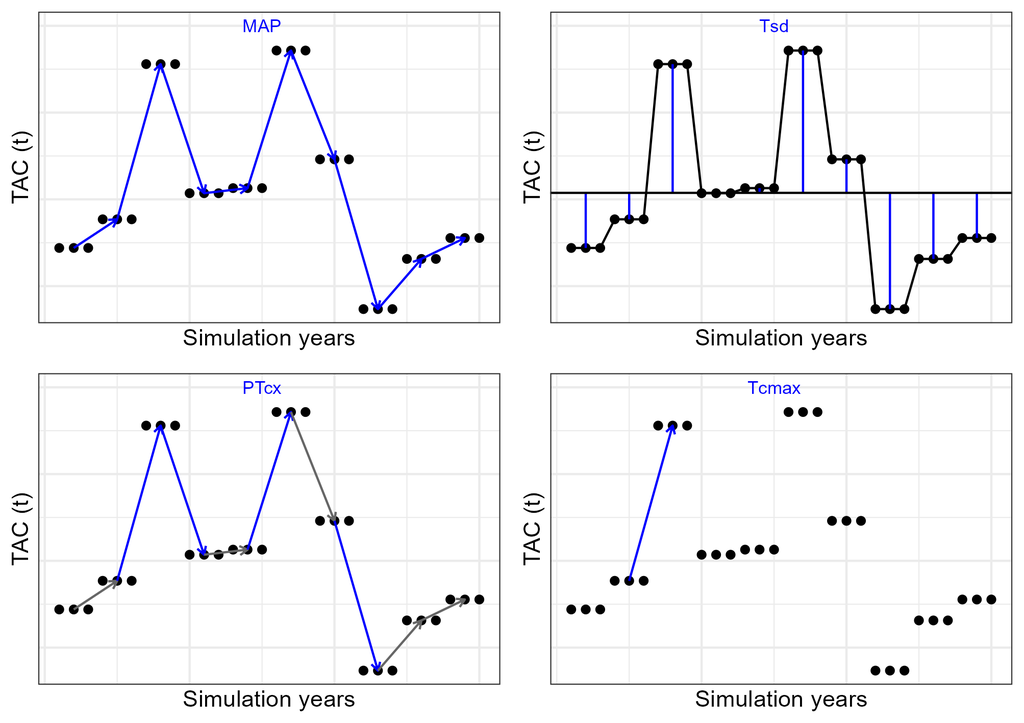

Figure 15: Stability performance indicators. The blue lines, arrows, or dots indicate the meaning of the metric. Find more details in Table 4.

## 7 Glossary

| Term | Definition |
| --- | --- |
| N-ALB | North Atlantic Albacore |
| OM | Operating model |
| CMP | Candidate management procedure |
| PI | Performance indicator |
| ALBSG | Albacore Species Group |
| SS3 | Stock Synthesis 3 platform |
| ESS | Effective sample size |
| CAAL | Conditional age-at-length |
| M | Natural mortality |
| sigmaR | Variability in recruitment |
| h | Steepness in the stock-recruit function |
| OEM | Observation error model |
| HCR | Harvest control rule |
| TAC | Total Allowable Catch |

## References

Fournier, D.A., Hampton, J., Sibert, J.R., 1998. MULTIFAN-CL: A length-based, age-structured model for fisheries stock assessment, with application to South Pacific albacore, *Thunnus* *Alalunga*. Canadian Journal of Fisheries and Aquatic Sciences 55, 2105–2116. https://doi.org/10.1139/f98-100

Francis, R.I.C.C., 2011. Data weighting in statistical fisheries stock assessment models. Canadian Journal of Fisheries and Aquatic Sciences 68, 1124–1138. https://doi.org/10.1139/f2011-025

Garcia, D., Sánchez, S., Prellezo, R., Urtizberea, A., Andrés, M., 2017. FLBEIA: A simulation model to conduct Bio-Economic evaluation of fisheries management strategies. SoftwareX 6, 141–147. https://doi.org/10.1016/j.softx.2017.06.001

Hamel, O.S., Cope, J.M., 2022. Development and considerations for application of a longevity-based prior for the natural mortality rate. Fisheries Research 256, 106477. https://doi.org/10.1016/j.fishres.2022.106477

ICCAT, 2023. [Report of the 2023 ICCAT Atlantic albacore stock assessment meeting (including MSE)](https://www.iccat.int/Documents/CVSP/CV080_2023/n_3/CV080030175.pdf) (No. SCRS/2023/010). ICCAT (International Commission for the Conservation of Atlantic Tunas).

Lorenzen, K., 1996. The relationship between body weight and natural mortality in juvenile and adult fish: A comparison of natural ecosystems and aquaculture. Journal of Fish Biology 49, 627–642. https://doi.org/10.1111/j.1095-8649.1996.tb00060.x

Merino, G., De Bruyn, P., Scott, G.P., Kell, L., Arrizabalaga, H., 2014. [A preliminary stock assessment for northern albacore using the fully integrated stock assessment model, MULTIFAN-CL](https://www.iccat.int/Documents/CVSP/CV070_2014/n_3/CV070031094.pdf) (No. SCRS/2013/058). ICCAT (International Commission for the Conservation of Atlantic Tunas).

Merino, G., Kell, L., Arrizabalaga, H., Santiago, J., 2020. [Updated consolidated report for North Atlantic albacore management strategy evaluation](https://www.iccat.int/Documents/CVSP/CV077_2020/n_7/CV077070428.pdf) (No. SCRS/2020/153). ICCAT (International Commission for the Conservation of Atlantic Tunas).

Methot, R.D., Wetzel, C.R., 2013. Stock synthesis: A biological and statistical framework for fish stock assessment and fishery management. Fisheries Research 142, 86–99. https://doi.org/10.1016/j.fishres.2012.10.012

Pedersen, M.W., Berg, C.W., 2017. A stochastic surplus production model in continuous time. Fish and Fisheries 18, 226–243. https://doi.org/10.1111/faf.12174

Schnute, J., 1981. A versatile growth model with statistically stable parameters. Canadian Journal of Fisheries and Aquatic Sciences 38, 1128–1140. https://doi.org/10.1139/f81-153